# Unit Project 02

2026-01-29

```r
library(tidyverse)
library(palmerpenguins)
penguins <- penguins %>%
  drop_na(flipper_length_mm, body_mass_g, bill_length_mm, bill_depth_mm, sex)
```

# *Lecture 06*

# GGPLOT

## Q1

Biscoe island had the most count of penguins.

Without theme minimal we could still see the bar plot, however, it did make the plot look cleaner and removed the gray background. It also added light gridlines

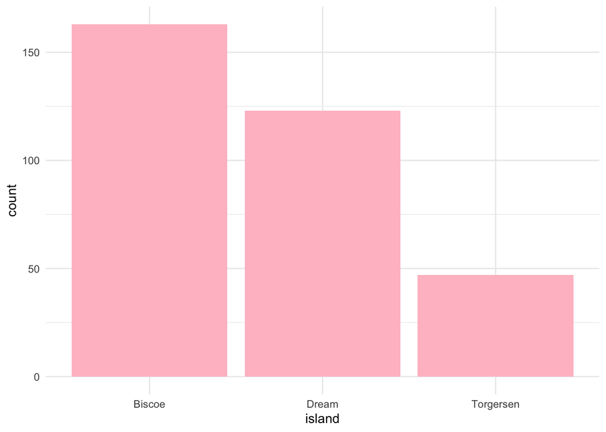

```r
ggplot(penguins, aes(x=island)) +
  geom_bar(fill="pink") +
  theme_minimal()
```

## Q2

The general shape seems to be bimodial

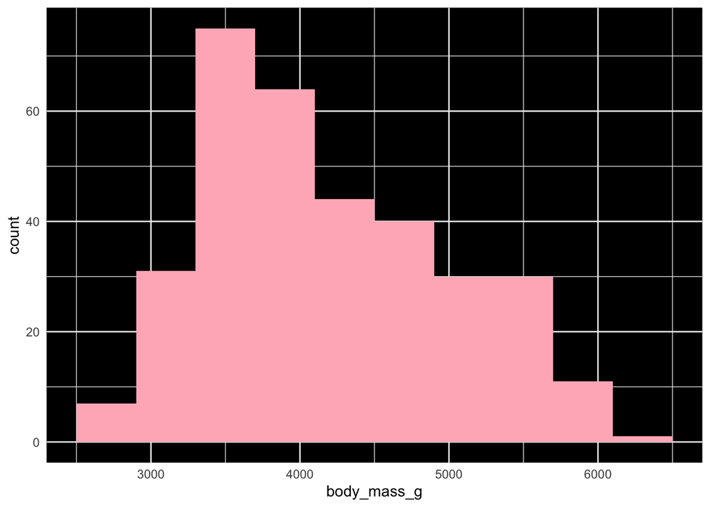

```r
ggplot(penguins, aes(x=body_mass_g)) +
  geom_histogram(bins = 10, fill = "lightpink") +
  theme_minimal() +
  theme(panel.background = element_rect(fill="black"))
```

bins 30

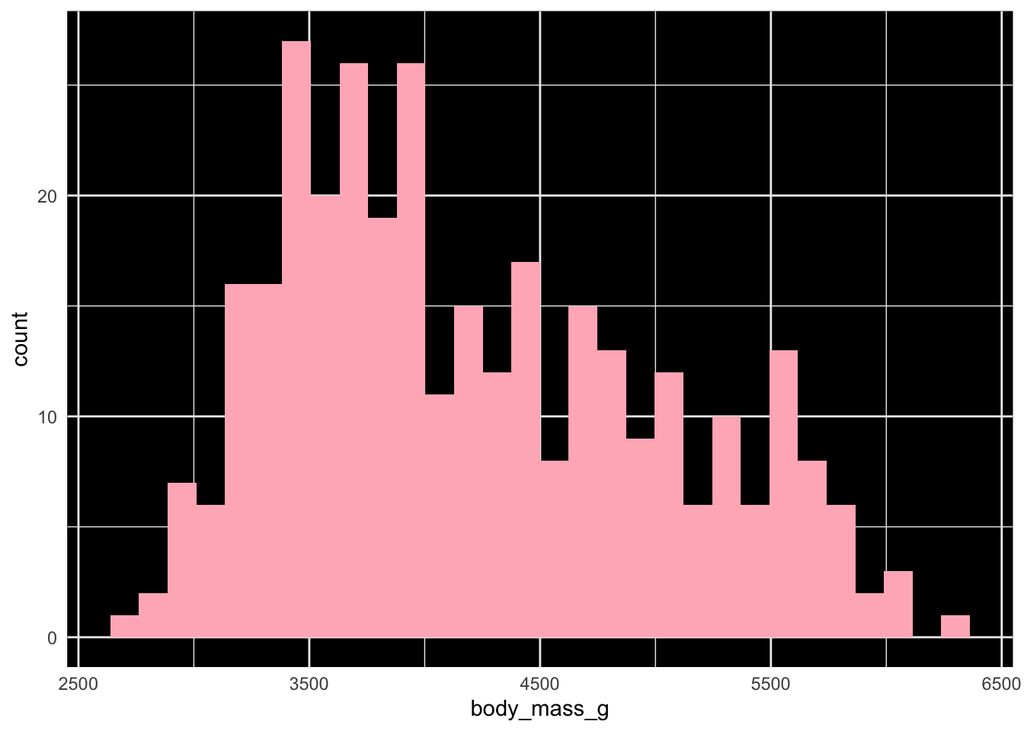

```r
ggplot(penguins, aes(x=body_mass_g)) +
  geom_histogram(bins = 30, fill = "lightpink") +
  theme_minimal() +
  theme(panel.background = element_rect(fill="black"))
```

bin 60

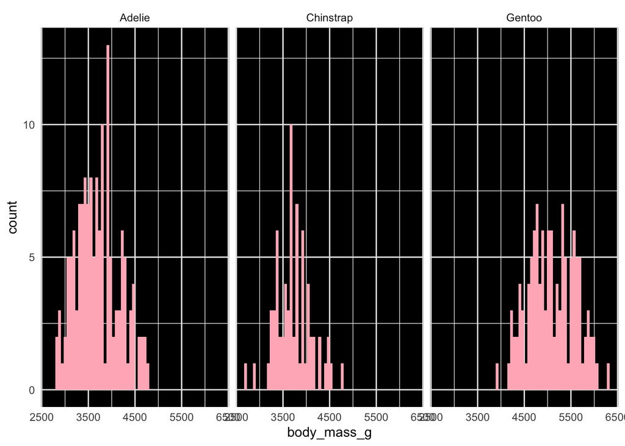

```r
  ggplot(penguins, aes(x=body_mass_g)) +
  geom_histogram(bins = 60, fill = "lightpink") +
  facet_wrap(~species) +
  theme_minimal() +
  theme(panel.background = element_rect(fill="black"))
```

Higher bin number makes the bars narrower and gives a more detailed representation of the data with smaller range of x values.

# BOXPLOTS

## Q3

### part 1

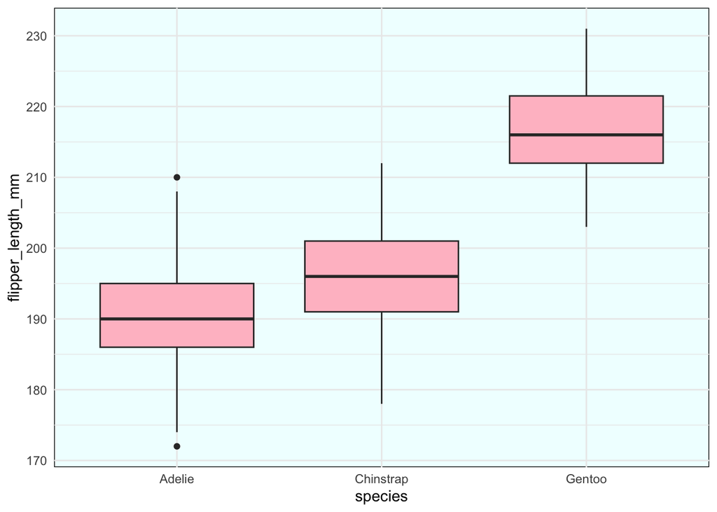

```r
ggplot(penguins, aes(x=species, y=flipper_length_mm)) +
  geom_boxplot(fill = "pink") +
  theme_minimal() +
  theme(panel.background = element_rect(fill="azure1"))
```

### part 2

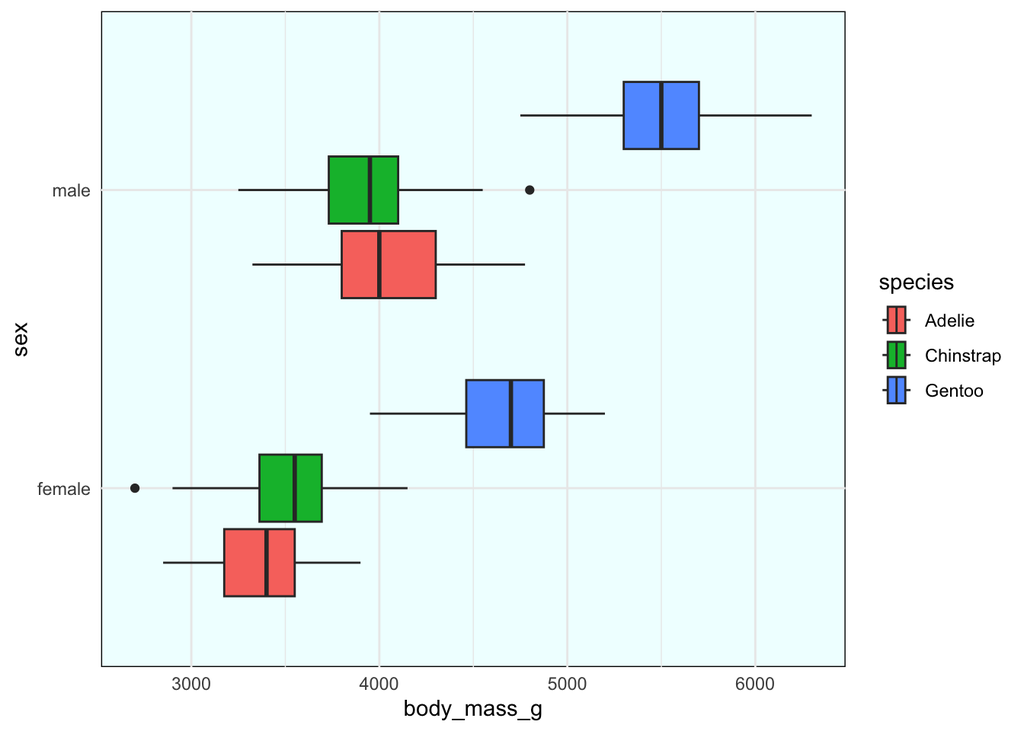

```r
ggplot(penguins, aes(x=body_mass_g, y=sex, fill = species)) +
  geom_boxplot() +
  theme_minimal() +
  theme(panel.background = element_rect(fill="azure1"))
```

Male and female species do differ in mass, female species seem to be in lower mass range than the male ones. Adding fill=species does help with readability, it colors the inside of shapes based on the species category.

# Scatterplots

## Q4

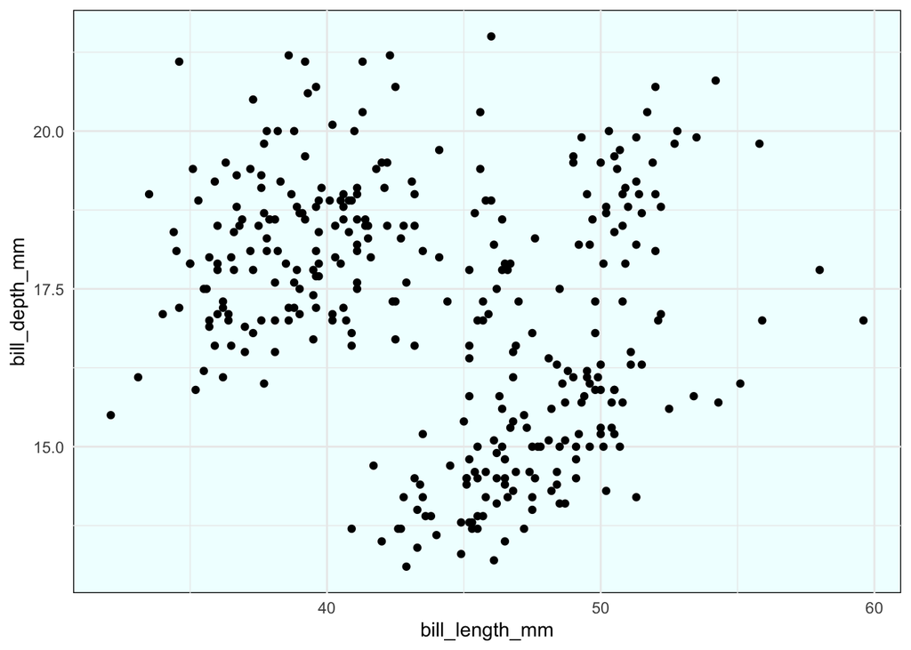

```r
ggplot(penguins, aes(x=bill_length_mm, y=bill_depth_mm)) +
  geom_point() +
  theme_minimal() +
  theme(panel.background = element_rect(fill="azure1"))
```

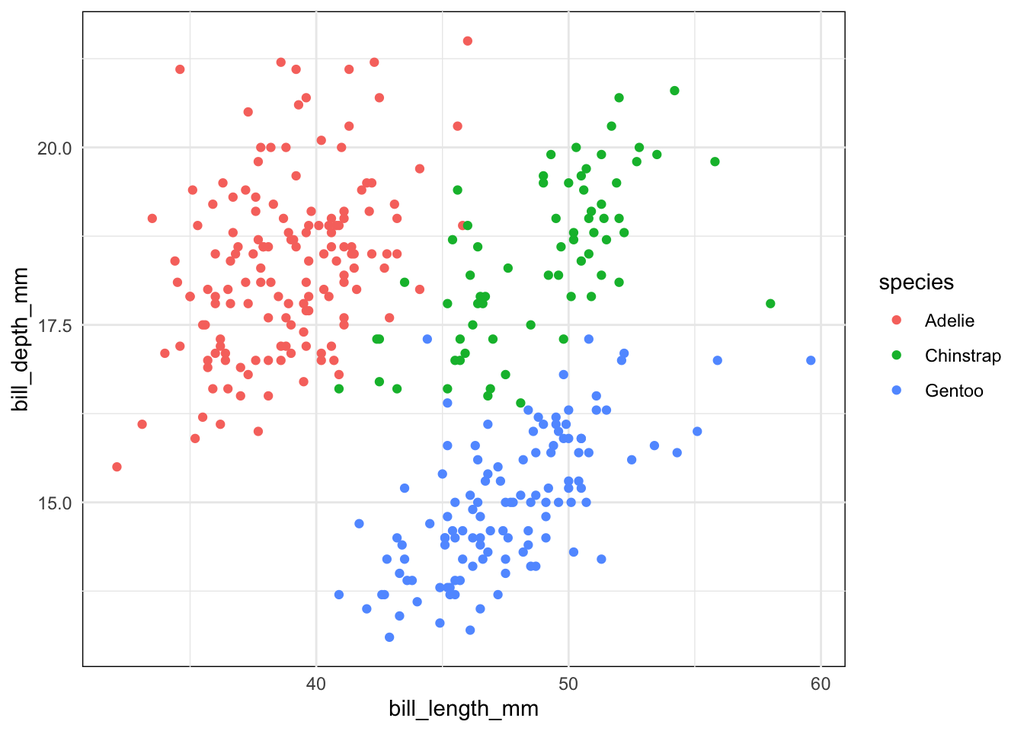

```r
ggplot(penguins, aes(x=bill_length_mm, y=bill_depth_mm, color = species)) +
  geom_point() +
  theme_minimal() +
  theme(panel.background = element_rect())
```

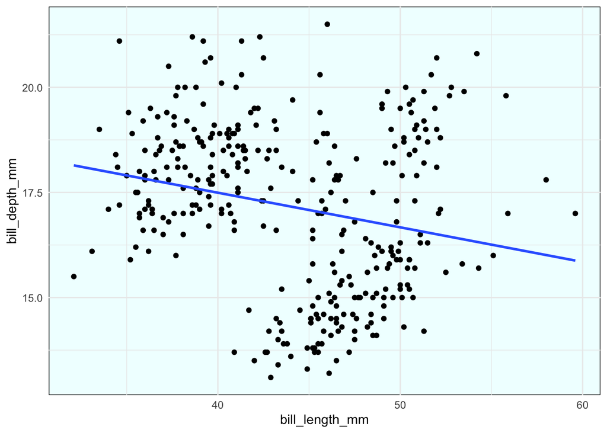

```r
ggplot(penguins, aes(x=bill_length_mm, y=bill_depth_mm)) +
  geom_point() +
  geom_smooth(method = "lm", se = FALSE) +
  theme_minimal() +
  theme(panel.background = element_rect(fill="azure1"))
```

The line doesn’t fit the data perfectly but it does showcase the negative relation.

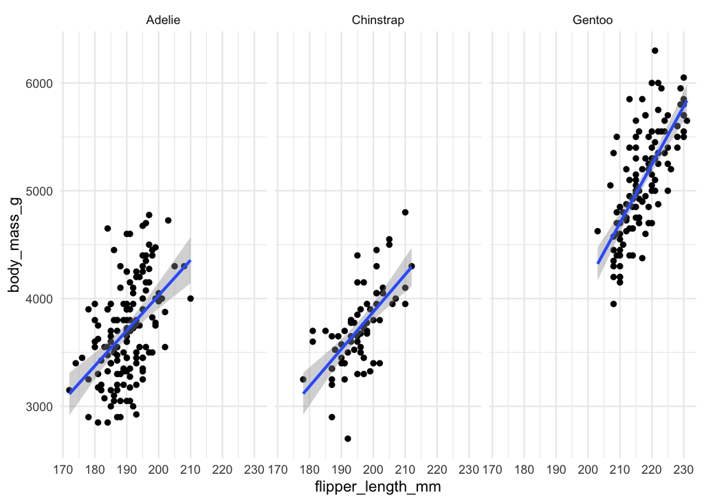

```r
ggplot(penguins, aes(x=flipper_length_mm, y=body_mass_g)) +
  geom_point() +
  facet_wrap(~species) +
  geom_smooth(method = "lm") +
  theme_minimal()
```

I would say gentoo seems to have the strongest relationship.

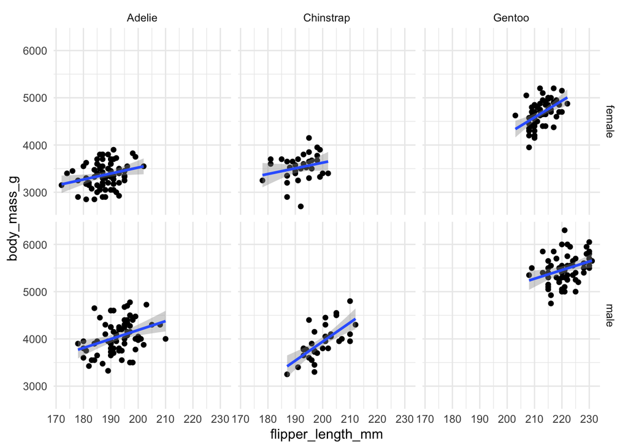

```r
ggplot(penguins, aes(x=flipper_length_mm, y=body_mass_g)) +
  geom_point() +
  facet_grid(sex~species) +
  geom_smooth(method = "lm") +
  theme_minimal()
```

For all the species there seems to be a positive relation between body mass and flipper length. Adding facet_grid also seperates the species by sex.

# Create a complex figure

## Q6

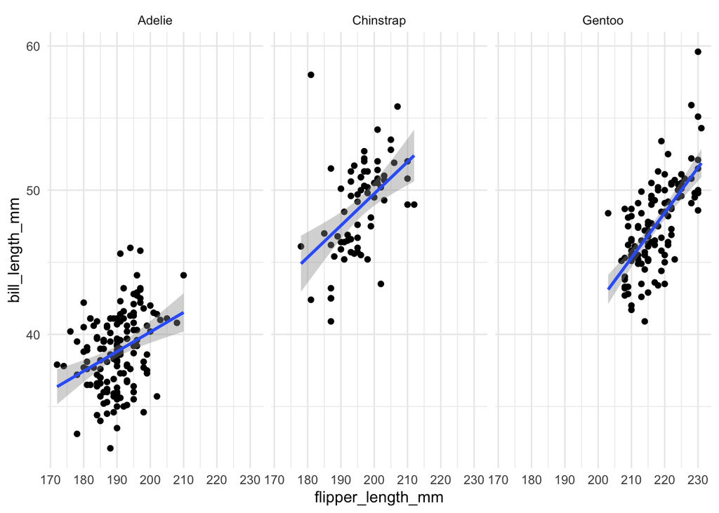

```r
ggplot(penguins, aes(x=flipper_length_mm, y=bill_length_mm)) +
  geom_point() +
  facet_wrap(~species) +
  geom_smooth(method = "lm") +
  theme_minimal()
```

# REFLECTION

The most fun part for me was toggling with the colors to make it look cuter, Dr Samuk taught me how to change the background color. Other than that it was also fun to observe the different graphs and the most confusing part was facet i’m skill kind of confused on difference between facet wrap and facet grid

# *Lecture 07*

```r
penguins_messy <- read.csv("penguins_messy.csv")
library(stringr)
library(dplyr)
```

## Q1

str_detect checks the values in species_messy to see if any contain the word “adelie”

str_replace_all checks the values in spring_messy and gets rid of ?

str_squish cleans extra space in island_messy

```r
str_detect(penguins_messy$species_messy, "adelie")
```

```
##   [1]  TRUE  TRUE  TRUE  TRUE  TRUE  TRUE  TRUE  TRUE  TRUE  TRUE  TRUE  TRUE
##  [13]  TRUE  TRUE  TRUE  TRUE  TRUE  TRUE  TRUE  TRUE  TRUE  TRUE  TRUE  TRUE
##  [25]  TRUE  TRUE  TRUE  TRUE  TRUE  TRUE  TRUE  TRUE  TRUE  TRUE  TRUE  TRUE
##  [37]  TRUE  TRUE  TRUE  TRUE  TRUE  TRUE  TRUE  TRUE  TRUE  TRUE  TRUE  TRUE
##  [49]  TRUE  TRUE  TRUE  TRUE  TRUE  TRUE  TRUE  TRUE  TRUE  TRUE  TRUE  TRUE
##  [61]  TRUE  TRUE  TRUE  TRUE  TRUE  TRUE  TRUE  TRUE  TRUE  TRUE  TRUE  TRUE
##  [73]  TRUE  TRUE  TRUE  TRUE  TRUE  TRUE  TRUE  TRUE  TRUE  TRUE  TRUE  TRUE
##  [85]  TRUE  TRUE  TRUE  TRUE  TRUE  TRUE  TRUE  TRUE  TRUE  TRUE  TRUE  TRUE
##  [97]  TRUE  TRUE  TRUE  TRUE  TRUE  TRUE  TRUE  TRUE  TRUE  TRUE  TRUE  TRUE
## [109]  TRUE  TRUE  TRUE  TRUE  TRUE  TRUE  TRUE  TRUE  TRUE  TRUE  TRUE  TRUE
## [121]  TRUE  TRUE  TRUE  TRUE  TRUE  TRUE  TRUE  TRUE  TRUE  TRUE  TRUE  TRUE
## [133]  TRUE  TRUE  TRUE  TRUE  TRUE  TRUE  TRUE  TRUE  TRUE  TRUE  TRUE  TRUE
## [145]  TRUE  TRUE  TRUE  TRUE  TRUE  TRUE  TRUE  TRUE FALSE FALSE FALSE FALSE
## [157] FALSE FALSE FALSE FALSE FALSE FALSE FALSE FALSE FALSE FALSE FALSE FALSE
## [169] FALSE FALSE FALSE FALSE FALSE FALSE FALSE FALSE FALSE FALSE FALSE FALSE
## [181] FALSE FALSE FALSE FALSE FALSE FALSE FALSE FALSE FALSE FALSE FALSE FALSE
## [193] FALSE FALSE FALSE FALSE FALSE FALSE FALSE FALSE FALSE FALSE FALSE FALSE
## [205] FALSE FALSE FALSE FALSE FALSE FALSE FALSE FALSE FALSE FALSE FALSE FALSE
## [217] FALSE FALSE FALSE FALSE FALSE FALSE FALSE FALSE FALSE FALSE FALSE FALSE
## [229] FALSE FALSE FALSE FALSE FALSE FALSE FALSE FALSE FALSE FALSE FALSE FALSE
## [241] FALSE FALSE FALSE FALSE FALSE FALSE FALSE FALSE FALSE FALSE FALSE FALSE
## [253] FALSE FALSE FALSE FALSE FALSE FALSE FALSE FALSE FALSE FALSE FALSE FALSE
## [265] FALSE FALSE FALSE FALSE FALSE FALSE FALSE FALSE FALSE FALSE FALSE FALSE
## [277] FALSE FALSE FALSE FALSE FALSE FALSE FALSE FALSE FALSE FALSE FALSE FALSE
## [289] FALSE FALSE FALSE FALSE FALSE FALSE FALSE FALSE FALSE FALSE FALSE FALSE
## [301] FALSE FALSE FALSE FALSE FALSE FALSE FALSE FALSE FALSE FALSE FALSE FALSE
## [313] FALSE FALSE FALSE FALSE FALSE FALSE FALSE FALSE FALSE FALSE FALSE FALSE
## [325] FALSE FALSE FALSE FALSE FALSE FALSE FALSE FALSE FALSE FALSE FALSE FALSE
## [337] FALSE FALSE FALSE FALSE FALSE FALSE FALSE FALSE
```

```r
str_replace_all(penguins_messy$sex_messy, "\\?", "")
```

```
##   [1] "M" "f" "f" NA  "f" "M" "f" "M" NA  NA  NA  NA  "f" "M" "M" "f" "f" "M"
##  [19] "f" "M" "f" "M" "f" "M" "M" "f" "M" "f" "f" "M" "f" "M" "f" "M" "f" "M"
##  [37] "M" "f" "f" "M" "f" "M" "f" "M" "f" "M" "M" NA  "f" "M" "f" "M" "f" "M"
##  [55] "f" "M" "f" "M" "f" "M" "f" "M" "f" "M" "f" "M" "f" "M" "f" "M" "f" "M"
##  [73] "f" "M" "f" "M" "f" "M" "f" "M" "f" "M" "f" "M" "f" "M" "M" "f" "M" "f"
##  [91] "f" "M" "f" "M" "f" "M" "f" "M" "f" "M" "f" "M" "f" "M" "f" "M" "f" "M"
## [109] "f" "M" "f" "M" "f" "M" "f" "M" "f" "M" "f" "M" "f" "M" "f" "M" "f" "M"
## [127] "f" "M" "f" "M" "f" "M" "f" "M" "f" "M" "f" "M" "f" "M" "f" "M" "f" "M"
## [145] "f" "M" "M" "f" "f" "M" "f" "M" "f" "M" "f" "M" "M" "f" "f" "M" "f" "M"
## [163] "f" "M" "f" "M" "f" "M" "f" "M" "f" "M" "M" "f" "f" "M" "f" "M" NA  "M"
## [181] "f" "M" "M" "f" "f" "M" "f" "M" "f" "M" "f" "M" "f" "M" "f" "M" "M" "f"
## [199] "f" "M" "f" "M" "f" "M" "f" "M" "f" "M" "f" "M" "f" "M" "f" "M" "f" "M"
## [217] "f" "M" NA  "M" "f" "M" "f" "M" "M" "f" "f" "M" "f" "M" "f" "M" "f" "M"
## [235] "f" "M" "f" "M" "f" "M" "f" "M" "f" "M" "f" "M" "f" "M" "M" "f" "f" "M"
## [253] "f" "M" "f" "M" NA  "M" "f" "M" "f" "M" "f" "M" "f" "M" "f" "M" NA  "M"
## [271] "f" NA  "f" "M" "f" "M" "f" "M" "M" "f" "M" "f" "f" "M" "f" "M" "f" "M"
## [289] "f" "M" "f" "M" "M" "f" "f" "M" "f" "M" "f" "M" "f" "M" "f" "M" "f" "M"
## [307] "f" "M" "f" "M" "M" "f" "f" "M" "f" "M" "M" "f" "M" "f" "f" "M" "f" "M"
## [325] "M" "f" "f" "M" "f" "M" "f" "M" "f" "M" "M" "f" "M" "f" "f" "M" "f" "M"
## [343] "M" "f"
```

```r
str_squish(penguins_messy$island_messy)
```

```
##   [1] "Torgersen" "Torgersen" "Torgersen" "Torgersen" "Torgersen" "Torgersen"
##   [7] "Torgersen" "Torgersen" "Torgersen" "Torgersen" "Torgersen" "Torgersen"
##  [13] "Torgersen" "Torgersen" "Torgersen" "Torgersen" "Torgersen" "Torgersen"
##  [19] "Torgersen" "Torgersen" "BIS-COE"   "BIS-COE"   "BIS-COE"   "BIS-COE"
##  [25] "BIS-COE"   "BIS-COE"   "BIS-COE"   "BIS-COE"   "BIS-COE"   "BIS-COE"
##  [31] "Dream"     "Dream"     "Dream"     "Dream"     "Dream"     "Dream"
##  [37] "Dream"     "Dream"     "Dream"     "Dream"     "Dream"     "Dream"
##  [43] "Dream"     "Dream"     "Dream"     "Dream"     "Dream"     "Dream"
##  [49] "Dream"     "Dream"     "BIS-COE"   "BIS-COE"   "BIS-COE"   "BIS-COE"
##  [55] "BIS-COE"   "BIS-COE"   "BIS-COE"   "BIS-COE"   "BIS-COE"   "BIS-COE"
##  [61] "BIS-COE"   "BIS-COE"   "BIS-COE"   "BIS-COE"   "BIS-COE"   "BIS-COE"
##  [67] "BIS-COE"   "BIS-COE"   "Torgersen" "Torgersen" "Torgersen" "Torgersen"
##  [73] "Torgersen" "Torgersen" "Torgersen" "Torgersen" "Torgersen" "Torgersen"
##  [79] "Torgersen" "Torgersen" "Torgersen" "Torgersen" "Torgersen" "Torgersen"
##  [85] "Dream"     "Dream"     "Dream"     "Dream"     "Dream"     "Dream"
```

[output cut: 43 more lines]

## Q2 number of rows = 316

```r
penguins_messy %>%
  mutate(valid_id = str_detect(sample_id, "^PAL-[0-9]{3}$")) %>%
  pull(valid_id) %>%
  sum(na.rm = TRUE)
```

```
## [1] 316
```

## Q3

```r
penguins_messy <- penguins_messy %>%
  mutate(valid_id = str_detect(sample_id, "^PAL-[0-9]{3}$"))

penguins_messy <- penguins_messy %>%
filter(valid_id)
```

## Q4

```r
penguins_messy <- penguins_messy %>%
mutate(file_date = str_extract(file_name, "^[0-9]{4}-[0-9]{2}-[0-9]{2}")) %>%
mutate(file_id = str_extract(file_name, "PAL-[0-9]{3}"))

names(penguins_messy)
```

```
## [1] "species_messy" "island_messy"  "sex_messy"     "sample_id"
## [5] "file_name"     "notes"         "valid_id"      "file_date"
## [9] "file_id"
```

```r
head(penguins_messy$file_date)
```

```
## [1] "2024-01-14" "2024-01-17" "2024-01-08" "2024-01-26" "2024-01-06"
## [6] "2024-01-08"
```

```r
head(penguins_messy$file_id)
```

```
## [1] "PAL-535" "PAL-442" "PAL-668" "PAL-920" "PAL-223" "PAL-899"
```

## Q5

“Torgersen” “BIS-COE” “Dream”

```r
penguins_messy <- penguins_messy %>%
mutate(island = str_squish(island_messy))

unique(penguins_messy$island)
```

```
## [1] "Torgersen" "BIS-COE"   "Dream"
```

## Q6

```r
penguins_messy <- penguins_messy %>%
mutate(sex = str_to_upper(str_replace_all(penguins_messy$sex_messy, "\\?", "")))

unique(penguins_messy$sex)
```

```
## [1] "M" "F" NA
```

## Q7

```r
penguins_messy <- penguins_messy %>%
  mutate(
    bill_mm = as.numeric(
      str_replace_all(notes, "(.*bill=)|mm", "")
    )
  )
```

## Reflection:

The most interesting part of the exercise was using regular expressions to pull numbers out of messy text and the hardest part was understanding what the symbols in the regex meant, especially things like .*, |, and parentheses. It’s not very intuitive at first, and it’s easy to remove too much or too little text if the pattern is slightly wrong.#

*Lecture 08*

penguins <- palmerpenguins::penguins

## Question 1

```r
penguins_clean <- penguins %>%
drop_na(bill_length_mm, sex)

penguins_clean
```

```
## # A tibble: 333 × 8
##    species island    bill_length_mm bill_depth_mm flipper_length_mm body_mass_g
##    <fct>   <fct>              <dbl>         <dbl>             <int>       <int>
##  1 Adelie  Torgersen           39.1          18.7               181        3750
##  2 Adelie  Torgersen           39.5          17.4               186        3800
##  3 Adelie  Torgersen           40.3          18                 195        3250
##  4 Adelie  Torgersen           36.7          19.3               193        3450
##  5 Adelie  Torgersen           39.3          20.6               190        3650
##  6 Adelie  Torgersen           38.9          17.8               181        3625
##  7 Adelie  Torgersen           39.2          19.6               195        4675
##  8 Adelie  Torgersen           41.1          17.6               182        3200
##  9 Adelie  Torgersen           38.6          21.2               191        3800
## 10 Adelie  Torgersen           34.6          21.1               198        4400
## # ℹ 323 more rows
## # ℹ 2 more variables: sex <fct>, year <int>
```

```r
nrow(penguins_clean)
```

```
## [1] 333
```

```r
nrow(penguins)
```

```
## [1] 333
```

number of rows in penguins_clean after getting rid of NA is 333

## Question 2

```r
penguins_dup <- penguins_clean %>%
  bind_rows(slice_sample(penguins_clean, n = 30, replace = TRUE))

nrow(penguins_dup)
```

```
## [1] 363
```

number of rows after adding 30 samples is 363

```r
penguins_dup %>%
distinct %>%
nrow
```

```
## [1] 333
```

number of rows after removing duplicates is 333 duplicates can mess up data analysis by inflating sample sizes which could lead to skewed statistics..

## Question 3

```r
penguins_clean %>%
select(species, island, sex, where(is.numeric)) %>%
nrow
```

```
## [1] 333
```

number of rows when only selecting species, island, sex is 333

## Question 4

```r
penguins_clean %>%
select(starts_with("bill"))
```

```
## # A tibble: 333 × 2
##    bill_length_mm bill_depth_mm
##             <dbl>         <dbl>
##  1           39.1          18.7
##  2           39.5          17.4
##  3           40.3          18
##  4           36.7          19.3
##  5           39.3          20.6
##  6           38.9          17.8
##  7           39.2          19.6
##  8           41.1          17.6
##  9           38.6          21.2
## 10           34.6          21.1
## # ℹ 323 more rows
```

```r
penguins_clean %>%
  select(ends_with("_mm"))
```

```
## # A tibble: 333 × 3
##    bill_length_mm bill_depth_mm flipper_length_mm
##             <dbl>         <dbl>             <int>
##  1           39.1          18.7               181
##  2           39.5          17.4               186
##  3           40.3          18                 195
##  4           36.7          19.3               193
##  5           39.3          20.6               190
##  6           38.9          17.8               181
##  7           39.2          19.6               195
##  8           41.1          17.6               182
##  9           38.6          21.2               191
## 10           34.6          21.1               198
## # ℹ 323 more rows
```

```r
penguins_clean %>%
  select(matches("^(bill|flipper)"))
```

```
## # A tibble: 333 × 3
##    bill_length_mm bill_depth_mm flipper_length_mm
##             <dbl>         <dbl>             <int>
##  1           39.1          18.7               181
##  2           39.5          17.4               186
##  3           40.3          18                 195
##  4           36.7          19.3               193
##  5           39.3          20.6               190
##  6           38.9          17.8               181
##  7           39.2          19.6               195
##  8           41.1          17.6               182
##  9           38.6          21.2               191
## 10           34.6          21.1               198
## # ℹ 323 more rows
```

## Q5

```r
penguins_clean %>%
group_by(species) %>%
summarise(across(where(is.numeric), mean))
```

```
## # A tibble: 3 × 6
##   species   bill_length_mm bill_depth_mm flipper_length_mm body_mass_g  year
##   <fct>              <dbl>         <dbl>             <dbl>       <dbl> <dbl>
## 1 Adelie              38.8          18.3              190.       3706. 2008.
## 2 Chinstrap           48.8          18.4              196.       3733. 2008.
## 3 Gentoo              47.6          15.0              217.       5092. 2008.
```

Using across is better, as it is more time efficient and convenient.You can also reuse the same pattern to try multiple different codes.

## Q6

```r
penguins_categorized <- penguins_clean %>%
  mutate(
    bill_length = case_when(
      bill_length_mm < 40 ~ "short",
      bill_length_mm < 50 ~ "medium",
      bill_length_mm >= 50 ~ "long"
    )
  )

penguins_categorized
```

```
## # A tibble: 333 × 9
##    species island    bill_length_mm bill_depth_mm flipper_length_mm body_mass_g
##    <fct>   <fct>              <dbl>         <dbl>             <int>       <int>
##  1 Adelie  Torgersen           39.1          18.7               181        3750
##  2 Adelie  Torgersen           39.5          17.4               186        3800
##  3 Adelie  Torgersen           40.3          18                 195        3250
##  4 Adelie  Torgersen           36.7          19.3               193        3450
##  5 Adelie  Torgersen           39.3          20.6               190        3650
##  6 Adelie  Torgersen           38.9          17.8               181        3625
##  7 Adelie  Torgersen           39.2          19.6               195        4675
##  8 Adelie  Torgersen           41.1          17.6               182        3200
##  9 Adelie  Torgersen           38.6          21.2               191        3800
## 10 Adelie  Torgersen           34.6          21.1               198        4400
## # ℹ 323 more rows
## # ℹ 3 more variables: sex <fct>, year <int>, bill_length <chr>
```

## Q7

```r
instrument_meta <- tibble(
  instrument_id = c("caliper_A", "caliper_B", "caliper_C"),
  calibration_mm = c(0.2, 0.5, 1.0),
  manufacturer = c("Mitutoyo", "Fowler", "Generic")
)

penguins_instrumented <- penguins_clean %>%
  drop_na(bill_length_mm) %>%
  mutate(
    instrument_id = case_when(
      year == 2007 ~ "caliper_A",
      year == 2008 ~ "caliper_B",
      year == 2009 ~ "caliper_C"
    )
  ) %>%
  left_join(instrument_meta, by = "instrument_id")

ncol(penguins_instrumented)
```

```
## [1] 11
```

```r
ncol(penguins_clean)
```

```
## [1] 8
```

Number of Columns in penguins_instrumented is 11 and penguins_clean is 8

## Reflection

Using across and select() was the most fun part for me since I realize that I didn’t have to type in every column name, and it made coding way easier. Most confusing for me was figuring out the regex expressions.

This is definitely going to be useful later since grouping could be useful in various data analysis based works, specially if you are getting into reserch or genetics.